# Intuit Quickbooks Upgrade

- Team-lead GitLab id:10677111
- Group number: 4
- Group name: Group 4
- Team member names:Jiamei Chen;Homa Rafieian Kouhpaei; Xinyan Zhang; Lu Yao

## Setup

Please complete this R-markdown document with your group by answering the questions in `intuit-quickbooks.pdf` on Dropbox (week6/readings/). Create an HTML file with all your results and comments and push both the Rmarkdown and HTML file to GitLab when your team is done. All results MUST be reproducible (i.e., the TA and I must be able to recreate the HTML from the Rmarkdown file without changes or errors). This means that you should NOT use any R-packages that are not part of the rsm-msba-spark docker container.

This is the first group assignment for MGTA 455 and you will be using git and GitLab. If two people edit the same file at the same time you could get what is called a “merge conflict”. git will not decide for you who’s change to accept so the team-lead will have to determine which edits to use. To avoid merge conflicts, **always** click “pull” in Rstudio before you start working on a files. Then, when you are done, save and commit your changes, and then push them to GitLab. Make this a habit!

If multiple people are going to work on the assignment at the same time I recommend you work on different files. You can use `source` to include R-code in your Rmarkdown document or include other R(markdown) documents into the main assignment file.

Group work-flow tips as discussed during ICT in Summer II are shown below:

- Pull, edit, save, stage, commit, and push
- Schedule who does what and when
- Try to avoid working simultaneously on the same file
- If you are going to work simultaneously, do it in different files, e.g.,
  - assignment1_john.R, assignment1_susan.R, assignment1_wei.R
  - assignment_1a.R, assignment_1b.R, assignment_1c.R
- Use the `source` command to bring different pieces of code together into an Rmarkdown document or into an R-code file
- Alternatively, use *child* in Rmarkdown to include a part of a report
- For (very) big projects use ‘branches’ to avoid conflicts (and stay on your branch)

A graphical depiction of the group work-flow is shown below:

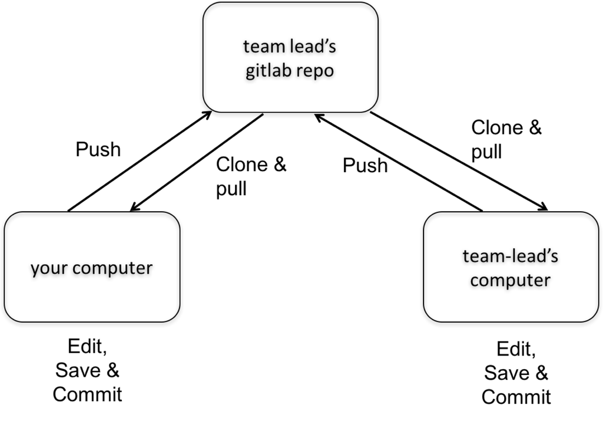

Additional resource on the use of git are linked below:

- http://happygitwithr.com
- http://r-pkgs.had.co.nz/git.html
- http://stackoverflow.com/questions/tagged/git or just a google search
- https://try.github.io
- https://www.manning.com/books/git-in-practice
- https://github.com/GitInPractice/GitInPractice#readme

```r
## loading the data. Note that data must be loaded from Dropbox/MGTA455-2019/data
intuit75k <- readr::read_rds(file.path(radiant.data::find_dropbox(), "MGTA455-2019/data/intuit75k.rds"))
intuit75k$zip_bins <- as.factor(intuit75k$zip_bins )
```

## Methodology:

create training and validation date:

```r
training <- intuit75k %>% filter(training == 1)
validation <- intuit75k %>% filter(training == 0)
```

## Create Models

### RFM:

RFM is a method used for analyzing customer value. It stands for three dimensions: recency, frequency and monetary. RFM is used to find the best customers. In this model, with amount of breakeven, we can calculate response rate and use it as the probability of responding for each customer.

```r
intuit75k <- intuit75k %>%
  mutate(rec_sq = xtile(last,5))

intuit75k <- intuit75k %>%
  group_by(rec_sq) %>%
  mutate(freq_sq = xtile(numords,5, rev = TRUE)) %>%
  ungroup()

intuit75k <- intuit75k %>%
  group_by(rec_sq, freq_sq) %>%
  mutate(mon_sq = xtile(dollars,5, rev = TRUE)) %>%
  ungroup()
intuit75k$rfm_sq <- paste0(intuit75k$rec_sq, intuit75k$freq_sq, intuit75k$mon_sq)

breakeven <- 1.41/60

small <-intuit75k %>% filter(training==1)
big <-intuit75k %>% filter(training==0)


small <- small %>%
  group_by(rfm_sq) %>%
  mutate(mailto_sq = mean(res1 == 'Yes') > breakeven , exp_response_rate_sq = sum(res1 == "Yes")/n()) %>%
  ungroup()

index <- small %>% select(rfm_sq,exp_response_rate_sq,mailto_sq) %>% unique()
big <- big %>% left_join(index)

rfm_result <- big %>% select(id,exp_response_rate_sq,mailto_sq)
```

```r
## calculate profit
performance <- data.frame(id = validation$id)
performance  <- performance %>%
  mutate(actual = validation$res1, prob_rfm = rfm_result$exp_response_rate_sq,mailto_rfm = rfm_result$mailto_sq)

perc_mail_rfm <- mean(performance$mailto_rfm)
dat <- filter(performance,mailto_rfm == TRUE)
rep_rate_rfm <- mean(dat$actual== "Yes")

cal_profit <- function(perc_mail,rep_rate,total_number){
  nr_mail <- total_number * perc_mail
  nr_resp <- nr_mail * rep_rate
  mail_cost <- 1.41 * nr_mail
  profit_logit <- 60 * nr_resp - mail_cost
  ROME_logit <- profit_logit / mail_cost
  result <- c(profit_logit,ROME_logit)
  return(result)
}

result_rfm <- cal_profit(perc_mail_rfm,rep_rate_rfm,22500)
```

calculate profit: the expected profit is $33498, the expected ROME is 128%.

### Naive Bayes:

The naive bayes model divide customer characteristics from training data into several data categories, then find the probability of each customer will respond to the wave1 according to the probability of each characteristic.

```r
result_nb <- nb(
  training,
  rvar = "res1",
  evar = c(
    "zip_bins", "sex", "bizflag", "numords", "dollars", "last",
    "sincepurch", "version1", "owntaxprod", "upgraded"
  )
)

pred_nb<-predict(result_nb,pred_data=training)
yes_nb<-pred_nb$Yes
no_nb<-pred_nb$No
training$yes_nb<-yes_nb
training$no_nb<-no_nb
training <- training %>%
  mutate(mailto_nb= yes_nb> breakeven)

pred_nb_validation<-predict(result_nb,pred_data=validation)
yes_nb_validation<-pred_nb_validation$Yes
no_nb_validation<-pred_nb_validation$No

performance$prob_nb<-yes_nb_validation
performance<- performance %>%
  mutate(mailto_nb= prob_nb> breakeven)
```

calculation profit: the expected profit is $36939, the expected ROME is 260%.

```r
perc_mail_nb <- mean(performance$mailto_nb)
dat_nb <- filter(performance, mailto_nb == TRUE)
rep_rate_nb<- mean(dat_nb$actual== "Yes")
result_nb <- cal_profit(perc_mail_nb,rep_rate_nb,22500)
```

### Logistic Model :

First, we made the distribution graph for all the numeric and category variables in this dataset, and found that the distribution of *dollars* and *sincepurch* are not uniform, so we did the log transformation to it. We used all variables to build the stepwise logistic regression, then we found not all variables are significant, so we delete some variables like “sex”, “sincepurch”, “bizflag”,etc.Then built the final model.

```r
## transform variable
training <- training %>%
  mutate(dollars_ln = log(dollars),sincepurch_ln = log(sincepurch))
validation <- validation %>%
  mutate(dollars_ln = log(dollars),sincepurch_ln = log(sincepurch))
mylist <- data.frame(col1 = seq(1,22500))
## logistic model and 100 times loop
set.seed(1234)
for(i in 1:100){
  validation_list <- data.frame(col1 = seq(1,22500))
  list <- sample_n(training,52500,replace = TRUE)
  list <- list %>%
  mutate(dollars_ln = log(dollars),sincepurch_ln = log(sincepurch))
  result <- logistic(
  list,
  rvar = "res1",
  evar = c(
    "zip_bins", "numords", "last", "version1", "owntaxprod",
    "upgraded", "dollars_ln"
  ),
  lev = "Yes",
)
  pred <- predict(result, pred_data = validation, conf_lev = 0.9, se = TRUE)
  validation_list <- store(validation_list, pred, name = "pred_logit")
  mylist <- cbind(mylist,validation_list$pred_logit)
}

colnames(mylist) <- seq(0,100)
mylist <- subset(mylist, select = -1 )

for(i in 1:22500){
  performance$prob_logit[i] <- quantile(mylist[i,],probs=0.05)
}

performance$prob_logit <- as.numeric(performance$prob_logit)
```

```r
## calculate profit
performance <- performance %>%
  mutate(mailto_logit = prob_logit > breakeven)

perc_mail_logit <- mean(performance$mailto_logit)
dat <- filter(performance,mailto_logit == TRUE)
rep_rate_logit <- mean(dat$actual == "Yes")
result_logit <- cal_profit(perc_mail_logit,rep_rate_logit,22500)
```

calculate profit: the expected profit is $37271, the expected ROME is 216%.

### Neural Networks:

```r
set.seed(1234)
predict_matrix = matrix(data= 0,nrow = 22500)
for (i in 1:100){
  table = data.frame(sample_n(training,size=500,replace =TRUE))
  result <- nn(
              table,
              rvar = "res1",
              evar = c(
                "zip_bins", "sex", "bizflag", "numords", "dollars", "last",
                "sincepurch", "version1", "owntaxprod", "upgraded"
              ),
              lev = "Yes",
              size = 3,
              seed = 1234
            )
  pred <- predict(result, pred_data = validation)
  nn_prediction <- c(pred$Prediction)
  predict_matrix <- cbind(predict_matrix,nn_prediction)
  }

predict_matrix <- predict_matrix[,-1] # delete the benchmark column
#str(predict_matrix)

quantile_5_vector <-c()
for (j in 1:22500){
      row <- unname(predict_matrix[j,])
      quantile_5_vector <- c(quantile_5_vector,unname(quantile(row,probs = 0.05)))}

performance$prob_nn<-quantile_5_vector
performance<- performance %>%
  mutate(mailto_nn= prob_nn> breakeven)
```

calculation profit: the expected profit is $24595, the expected ROME is 350%.

```r
perc_mail_nn <- mean(performance$mailto_nn)
dat_nn <- filter(performance, mailto_nn == TRUE)
rep_rate_nn<- mean(dat_nn$actual== "Yes")
result_nn <- cal_profit(perc_mail_nn,rep_rate_nn,22500)
```

## graph for profit and ROME

```r
## make a tibble (data.frame) with results
intuit_results <- tibble::tibble(
  name = c("RFM","Naive bayes","Logistic regression adjusted","Neural Network"),
  Profit = c(result_rfm[1],result_nb[1],result_logit[1],result_nn[1]),
  ROME = c(result_rfm[2],result_nb[2],result_logit[2],result_nn[2])
) %>%
  mutate(name = factor(name, levels = name))
register("intuit_results")
```

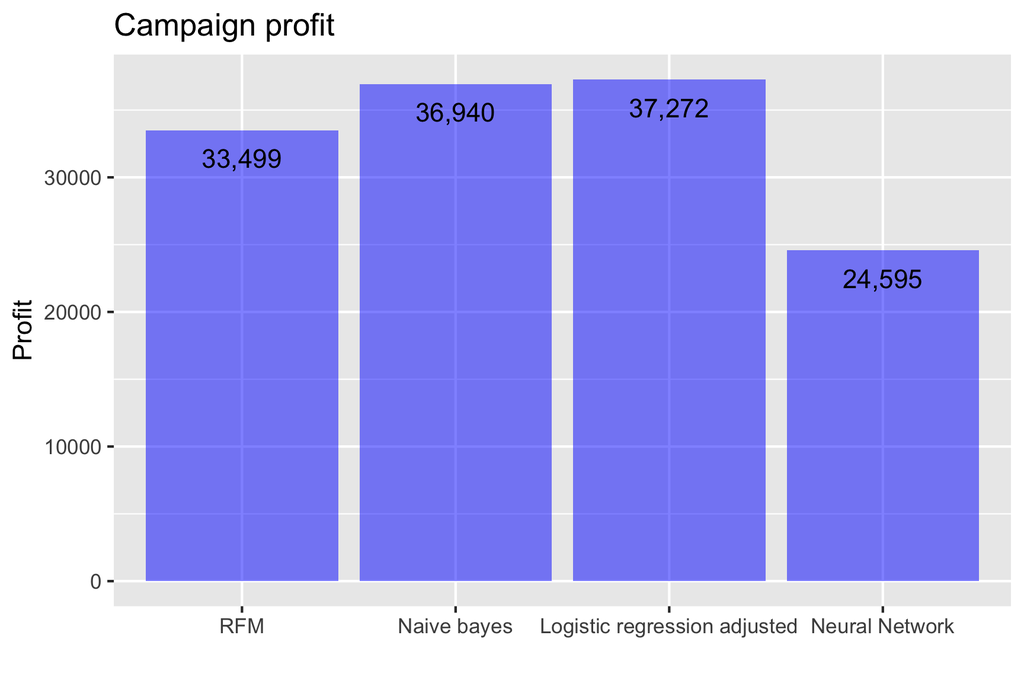

```r
## plot campaign profit
visualize(
  intuit_results,
  xvar = "name",
  yvar = "Profit",
  type = "bar",
  labs = list(title = "Campaign profit", x = ""),
  custom = TRUE
) +
  geom_text(aes(label = format_nr(Profit, dec = 0)), vjust = 2)
```

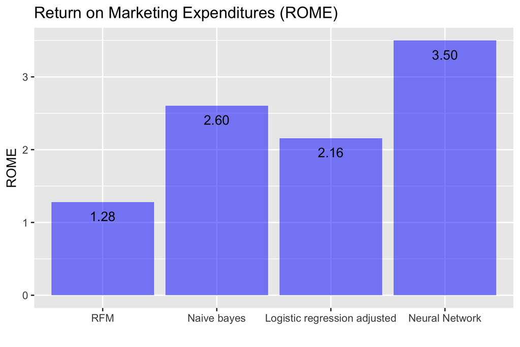

```r
## plot ROME
visualize(
  intuit_results,
  xvar = "name",
  yvar = "ROME",
  type = "bar",
  labs = list(title = "Return on Marketing Expenditures (ROME)", x = ""),
  custom = TRUE
) +
  geom_text(aes(label = format_nr(ROME, dec = 2)), vjust = 2)
```

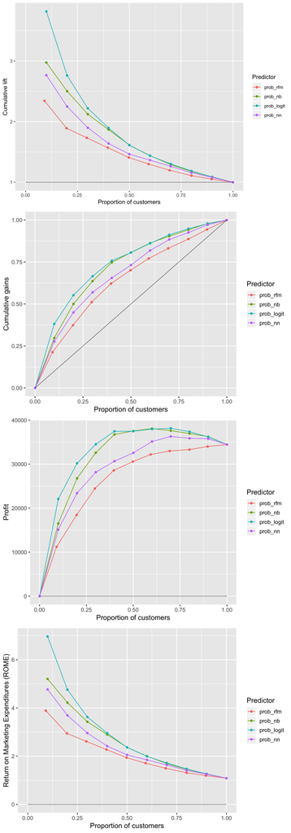

```r
result <- evalbin(
  performance,
  pred = c("prob_rfm", "prob_nb",'prob_logit','prob_nn'),
  rvar = "actual",
  lev = "Yes",
  cost = 1.41,
  margin = 60
)
#summary(result, prn = TRUE)
plot(
  result,
  plots = c("lift", "gains", "profit", "rome"),
  custom = FALSE
)
```

```r
result <- confusion(
  performance,
  pred = c("prob_rfm", "prob_nb",'prob_logit','prob_nn'),
  rvar = "actual",
  lev = "Yes",
  cost = 1.41,
  margin = 60
)
summary(result)
```

```
Confusion matrix
Data       : performance
Results for: All
Predictors : prob_rfm, prob_nb, prob_logit, prob_nn
Response   : actual
Level      : Yes in actual
Cost:Margin: 1.41 : 60

 Type  Predictor  TP     FP     TN  FN  total   TPR   TNR precision Fscore
  All   prob_rfm 994 17,546  3,851 109 22,500 0.901 0.180     0.054  0.101
  All    prob_nb 852  9,205 12,192 251 22,500 0.772 0.570     0.085  0.153
  All prob_logit 909 11,338 10,059 194 22,500 0.824 0.470     0.074  0.136
  All    prob_nn 527  4,455 16,942 576 22,500 0.478 0.792     0.106  0.173

 Type  Predictor accuracy kappa profit index  ROME contact   AUC
  All   prob_rfm    0.215 0.010 33,499 0.899 1.281   0.824 0.649
  All    prob_nb    0.580 0.071 36,940 0.991 2.605   0.447 0.729
  All prob_logit    0.487 0.051 37,272 1.000 2.158   0.544 0.754
  All    prob_nn    0.776 0.101 24,595 0.660 3.501   0.221 0.692
```

```r
performance_sub <- performance %>%
  filter(actual == "No")%>%
  mutate(dec_logit = xtile(prob_logit, 100, rev = TRUE))
```

```r
table <- explore(
  performance_sub,
  vars = "prob_logit",
  byvar = "dec_logit",
  fun = c("n_obs","mean"),
  nr = 100
)
#summary(table)
# dtab(result) %>% render()
```

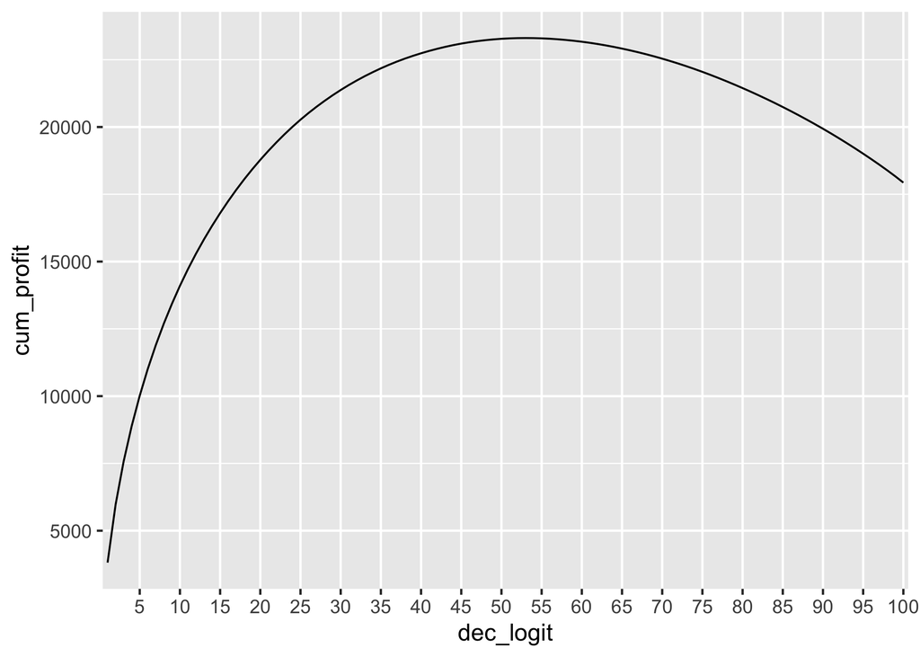

```r
logit_table<- table$tab
logit_table<-logit_table%>%
  mutate(res_num = n_obs * mean, profit = res_num *60 - n_obs*1.41, cum_profit = cumsum(profit))

logit_table %>%  ggplot(aes(x=dec_logit,y=cum_profit,group=1)) + geom_line() + scale_x_discrete(breaks=seq(0, 100, 5))
```

```r
first <- logit_table%>%
  arrange(desc(cum_profit)) %>%
  head(1)
number <- as.numeric(first$dec_logit)

final_id <- performance_sub%>%
  filter(dec_logit<=number) %>%
  select(id)
final_id <- final_id %>%
  mutate(mailto_wave2=TRUE)
```

After choosing logit model as our final model, we use it to make predictions on the target customers. First, we filter all customers in the validation set that did not respond to wave 1 as a sub-validation set. And we calculate the probability of each person in the sub-validation set. In addition, we calculate the accumulated profit of these customers after ordering them from largest to lowest. And we find the max profit is achieved when we select only the largest 53% customers. Thus, we decided to target only these people to maximize our profit.

In the validation set of 22500 rows, we filter out the customers have bought the product(which res1 = 1) ,then we use logistic model with adjusted to predict the probability of each customer. Then we divide them into 100 deciles according to probability, with every decile we add in ,we calculate the cumulative profit and finally find the maximum profit is $23305.22 * 0.5 = $11652 when decile equal to 53%. When it comes to 801,821 people, the anticipated profit becomes $415258.

```r
final_result <- performance %>%
  select(id) %>%
  left_join(final_id)

save(final_result, file = "Jiamei_Home_Xinyan_Lu_group4.rds" )
```